# Guía 5: El micrómetro

## Introducción

El **micrómetro** es un instrumento de medición de alta precisión utilizado para medir dimensiones lineales generalmente con una resolución de centésimas (0,01 mm) o milésimas de milímetro (0,001 mm).

Funciona mediante un tornillo micrométrico que convierte el movimiento rotatorio del tambor en un desplazamiento lineal muy preciso del husillo. Gracias a su diseño, permite realizar mediciones más exactas que otros instrumentos como calibre Vernier o pie de rey, siendo ideal para tareas de control de calidad en talleres y laboratorios.

Existen distintos tipos de micrómetros según su uso: exteriores, interiores y de profundidad.

## Actividad 1

Dibuja a mano alzada un micrómetro como el de la figura de abajo. Busca información y pon los siguientes nombres correctamente en las partes numeradas de la figura.

- Tope
- Husillo
- Tambor fijo, manga
- Tambor móvil, dedal
- Freno
- Trinquete
- Armazón o cuerpo

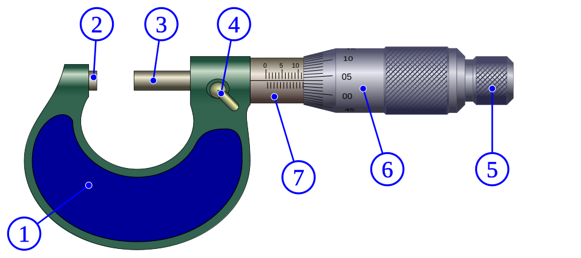

Source: Wikimedia Commons

## Tipos de micrómetro

Toca en cada tipo para ver una imagen del mosmo.

- Exterior: (Como el de la figura de arriba) mide espesores, diámetros exteriores.
- [Interior](https://upload.wikimedia.org/wikipedia/commons/thumb/b/b1/MicrometerInside5-30_25-50.jpg/250px-MicrometerInside5-30_25-50.jpg): mide diámetros internos (requiere puntas especiales).
- [De profundidad](https://upload.wikimedia.org/wikipedia/commons/thumb/4/4b/Micr%C3%B3metro_C05_0647.svg/960px-Micr%C3%B3metro_C05_0647.svg.png): mide la profundidad de ranuras, orificios o escalones.
- [Digital](https://upload.wikimedia.org/wikipedia/commons/thumb/d/de/Micrometro_micromaster.jpg/250px-Micrometro_micromaster.jpg): facilita la lectura en pantalla electrónica.

## Buenas prácticas de uso

- Limpiar la superficie de contacto antes de medir.
- Usar el trinquete, no forzar el giro.
- No tomar medidas en piezas calientes (por dilatación).
- Evitar golpes, humedad y polvo.
- Guardar en su estuche, con el husillo ligeramente abierto.
- Calibrar regularmente con bloques patrón.

## Actividad 2

Observe este [video](https://www.youtube.com/watch?v=l85MJ1j1w4g) y aprende a medir con el micrómetro. No tiene importancia la parte que habla de las líneas horizontales arriba de la escala de la manga (Tambor fijo).

- **1)** ¿Qué medida marca el micrómetro de la figura?

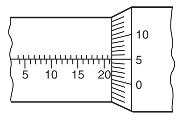

- **2)** Elija una pieza adecuada cualquiera, haga un esquema (dibujo) y tome con micrómetro alguna de las medidas de la pieza anotándola como una cota.

## Actividad 3

Esta guía no está aprobada hasta hacer este punto.

Pedir una pieza el profesor y medirla correctamente delante de él con el micrómetro. Además nombrar las partes del micrómetro.